# 《某电商平台订单异常检测》

# 项目介绍：

①数据来源：中国某电商企业的实际交易数据，数年后开放数据用于学习交流； ②数据量级：十万级； ③预测类型：分类型； ④项目需求：通过数据处理与分析，构建电商订单异常检测模型。

# 1.导入数据，进行基本特征信息挖掘和数据清洗

```python
import numpy as np
import pandas as pd
import matplotlib.pyplot as plt
%matplotlib inline

plt.rcParams['font.sans-serif']=['Simhei']      #显示中文
plt.rcParams['axes.unicode_minus']=False        #显示负号
```

## 1.1 导入原始数据：

```python
data = pd.read_csv(r"C:\Users\Hoboe\Desktop\数据分析\3天收获一份简历项目\abnormal_orders.txt")
```

```python
#查看数据导入情况：
data.head()
```

|  | order_id | order_date | order_time | cat | attribution | pro_id | pro_brand | total_money | total_quantity | order_source | pay_type | user_id | city | abnormal_label |
| --- | --- | --- | --- | --- | --- | --- | --- | --- | --- | --- | --- | --- | --- | --- |
| 0 | 4277880103 | 2013-10-17 | 13:09:16 | NaN | GO | 8000001215 | NaN | 1000.0 | 1000 | 游戏站点 | 当当支付 | murongchun | 北京市 | 0 |
| 1 | 4283851335 | 2013-09-23 | 14:09:49 | 手机摄影数码 | POP | 8002042497 | 三星 | 766000.0 | 200 | 主站 | 合并支付 | dakehu_zy | 上海市 | 1 |
| 2 | 4277700101 | 2013-08-27 | 14:26:38 | NaN | GO | 7000000960 | 国之美艺术品 | 8000.0 | 160 | do.site_id | 在线支付 | 1391175862 | NaN | 1 |
| 3 | 4276537082 | 2013-09-11 | 14:16:47 | 电视冰箱洗衣机空调 | POP | 8001992420 | 樱花 | 19900.0 | 100 | 主站 | 合并支付 | qq-3be293b | 泉州市 | 1 |
| 4 | 4281111595 | 2013-04-10 | 10:44:46 | 家具建材 | POP | 8002199518 | 纬度空间 | 100.0 | 100 | 主站 | 合并支付 | nonscorpio | 广州市 | 1 |

```python
data.shape
```

```
(134190, 14)
```

## 1.2 理解电商数据特征

▶订单日期（order_date）

```python
#查看订单日期的整体情况：
data['order_date'].value_counts()
#共有364个数据，并且每个日期的订单量差距很大，说明数据集应该是对全年数据的抽样。
```

```
2013-10-31    690
2013-03-21    429
2013-11-01    426
2013-01-24    422
2013-03-23    416
             ...
2013-07-31     17
2013-08-31     14
2013-01-31      2
2013-03-31      2
2013-05-31      2
Name: order_date, Length: 364, dtype: int64
```

▶订单id（order_id）

```python
#判断订单id是否存在重复
data['order_id'].duplicated().sum()
#所得结果不为零，说明id存在重复
```

```
19212
```

▶商品一级类别（cat）

```python
data['cat'].value_counts()
#可以看到类别集中在电子产品/家电/家居，可以初步判断商城的属性是偏家居的
```

```
手机摄影数码       20612
生活电器厨卫电器     19281
家纺寝居         18679
电脑办公打印文仪     11405
家居日用         10642
电视冰箱洗衣机空调     9067
美妆个护          9043
汽车用品          6490
家具建材          4941
食品酒水          4669
健康医疗          4252
服饰鞋帽          4067
运动户外          3934
母婴用品玩具        2664
箱包奢品          1962
钟表首饰           860
图书音像           232
Name: cat, dtype: int64
```

▶商品所属渠道（attribution）

```python
data['attribution'].value_counts()
#POP表示第三方供应商，推测GO表示平台自营
```

```
GO     91170
POP    43020
Name: attribution, dtype: int64
```

▶订单渠道（order_source）

```python
data['order_source'].value_counts()
#根据“充值”、“当当”等分类，推测该数据来源于国美
```

```
主站            96894
抢购            16256
手机站点           7098
团购             6294
手机抢购           3095
do.site_id     2394
手机团购           1074
充值              703
当当              377
游戏站点              5
Name: order_source, dtype: int64
```

▶查看数据的整体情况

```python
data.info()
#部门特征的数量小于134190，说明存在缺失值。
```

```
<class 'pandas.core.frame.DataFrame'>
RangeIndex: 134190 entries, 0 to 134189
Data columns (total 14 columns):
 #   Column          Non-Null Count   Dtype
---  ------          --------------   -----
 0   order_id        134190 non-null  int64
 1   order_date      134190 non-null  object
 2   order_time      134190 non-null  object
 3   cat             132800 non-null  object
 4   attribution     134190 non-null  object
 5   pro_id          134190 non-null  int64
 6   pro_brand       133418 non-null  object
 7   total_money     134189 non-null  float64
 8   total_quantity  134190 non-null  int64
 9   order_source    134190 non-null  object
 10  pay_type        134190 non-null  object
 11  user_id         134190 non-null  object
 12  city            134188 non-null  object
 13  abnormal_label  134190 non-null  int64
dtypes: float64(1), int64(4), object(9)
memory usage: 14.3+ MB
```

## 1.3 缺失值处理

```python
#每一列的缺失情况：
data.isnull().sum()

#可以看到缺失值主要存在于商品一级类别cat和品牌pro_brand 。
```

```
order_id             0
order_date           0
order_time           0
cat               1390
attribution          0
pro_id               0
pro_brand          772
total_money          1
total_quantity       0
order_source         0
pay_type             0
user_id              0
city                 2
abnormal_label       0
dtype: int64
```

```python
#每一列缺失值所占的百分比：
data.isnull().sum()/data.shape[0]*100

#所占比例并不高。
```

```
order_id          0.000000
order_date        0.000000
order_time        0.000000
cat               1.035845
attribution       0.000000
pro_id            0.000000
pro_brand         0.575304
total_money       0.000745
total_quantity    0.000000
order_source      0.000000
pay_type          0.000000
user_id           0.000000
city              0.001490
abnormal_label    0.000000
dtype: float64
```

```python
#查看缺失数据与标签（abnormal_label）的关联性：
for i in ["cat","pro_brand"]:
    ratio = 100 * data.loc[data[i].isnull(),"abnormal_label"].sum()/data[i].isnull().sum()
    print("({0})为缺失值的所有样本中，异常样本占{1:.3f}%。".format(i,ratio))

#可见，存在缺失值的样本和异常没有很强的关联性，缺失的样本可以直接删除。
```

```
(cat)为缺失值的所有样本中，异常样本占11.727%。
(pro_brand)为缺失值的所有样本中，异常样本占20.984%。
```

```python
#删除所有存在缺失值的样本：
data.dropna(how='any',inplace=True)
```

```python
#检查是否还存在缺失值：
data.isnull().sum().sum()
```

```
0
```

```python
#重新整理索引：
data.index = range(data.shape[0])
```

```python
data.shape
```

```
(132761, 14)
```

## 1.4 重复值处理

```python
data.duplicated().sum()
#显示存在8条重复样本，可以直接删除。
```

```
8
```

```python
#删除重复样本：
data.drop_duplicates(inplace=True)
data.shape
```

```
(132753, 14)
```

```python
data['order_id'].value_counts()

#可见有的订单id对应多个样本，推测样本与订单id不是一一对应，一个样本可能是同一个订单id下的不同商品。
```

```
4279118253    32
4269390206    23
4271884108    20
4275856215    20
4265415474    19
              ..
4146667708     1
4146667654     1
4146661886     1
4146657953     1
4285770056     1
Name: order_id, Length: 114207, dtype: int64
```

```python
#查看第一条订单id的数据：
data[data['order_id']==4279118253]
```

|  | order_id | order_date | order_time | cat | attribution | pro_id | pro_brand | total_money | total_quantity | order_source | pay_type | user_id | city | abnormal_label |
| --- | --- | --- | --- | --- | --- | --- | --- | --- | --- | --- | --- | --- | --- | --- |
| 95213 | 4279118253 | 2013-07-23 | 23:22:21 | 家具建材 | GO | 1000147804 | 西门子 | 10.6 | 1 | 主站 | 合并支付 | cxh0111 | 湛江市 | 0 |
| 95214 | 4279118253 | 2013-11-08 | 23:22:21 | 家具建材 | GO | 1000147804 | 西门子 | 10.6 | 1 | 主站 | 合并支付 | cxh0111 | 湛江市 | 0 |
| 95215 | 4279118253 | 2013-01-26 | 23:22:21 | 家具建材 | GO | 1000147606 | 西门子 | 20.6 | 1 | 主站 | 合并支付 | cxh0111 | 湛江市 | 0 |
| 95216 | 4279118253 | 2013-02-03 | 23:22:21 | 家具建材 | GO | 1000147606 | 西门子 | 20.6 | 1 | 主站 | 合并支付 | cxh0111 | 湛江市 | 0 |
| 95217 | 4279118253 | 2013-07-06 | 23:22:21 | 家具建材 | GO | 1000147606 | 西门子 | 20.6 | 1 | 主站 | 合并支付 | cxh0111 | 湛江市 | 0 |
| 95218 | 4279118253 | 2013-04-28 | 23:22:21 | 家具建材 | GO | 1000147826 | 西门子 | 10.6 | 1 | 主站 | 合并支付 | cxh0111 | 湛江市 | 0 |
| 95219 | 4279118253 | 2013-10-04 | 23:22:21 | 家具建材 | GO | 1000147826 | 西门子 | 10.6 | 1 | 主站 | 合并支付 | cxh0111 | 湛江市 | 0 |
| 95220 | 4279118253 | 2013-02-21 | 23:22:21 | 家具建材 | GO | 1000147826 | 西门子 | 10.6 | 1 | 主站 | 合并支付 | cxh0111 | 湛江市 | 0 |
| 95221 | 4279118253 | 2013-06-18 | 23:22:21 | 家具建材 | GO | 1000147826 | 西门子 | 10.6 | 1 | 主站 | 合并支付 | cxh0111 | 湛江市 | 0 |
| 95222 | 4279118253 | 2013-09-25 | 23:22:21 | 家具建材 | GO | 1000147826 | 西门子 | 10.6 | 1 | 主站 | 合并支付 | cxh0111 | 湛江市 | 0 |
| 95223 | 4279118253 | 2013-04-01 | 23:22:21 | 家具建材 | GO | 1000147826 | 西门子 | 10.6 | 1 | 主站 | 合并支付 | cxh0111 | 湛江市 | 0 |
| 95224 | 4279118253 | 2013-01-21 | 23:22:21 | 家具建材 | GO | 1000147827 | 西门子 | 18.6 | 1 | 主站 | 合并支付 | cxh0111 | 湛江市 | 0 |
| 95225 | 4279118253 | 2013-06-27 | 23:22:21 | 家具建材 | GO | 1000147827 | 西门子 | 18.6 | 1 | 主站 | 合并支付 | cxh0111 | 湛江市 | 0 |
| 95226 | 4279118253 | 2013-05-21 | 23:22:21 | 家具建材 | GO | 1000147827 | 西门子 | 18.6 | 1 | 主站 | 合并支付 | cxh0111 | 湛江市 | 0 |
| 95227 | 4279118253 | 2013-03-30 | 23:22:21 | 家具建材 | GO | 1000147827 | 西门子 | 18.6 | 1 | 主站 | 合并支付 | cxh0111 | 湛江市 | 0 |
| 95228 | 4279118253 | 2013-11-29 | 23:22:21 | 家具建材 | GO | 1000147827 | 西门子 | 18.6 | 1 | 主站 | 合并支付 | cxh0111 | 湛江市 | 0 |
| 95229 | 4279118253 | 2013-11-27 | 23:22:21 | 家具建材 | GO | 1000147827 | 西门子 | 18.6 | 1 | 主站 | 合并支付 | cxh0111 | 湛江市 | 0 |
| 95230 | 4279118253 | 2013-09-26 | 23:22:21 | 家具建材 | GO | 1000147827 | 西门子 | 18.6 | 1 | 主站 | 合并支付 | cxh0111 | 湛江市 | 0 |
| 95231 | 4279118253 | 2013-09-16 | 23:22:21 | 家具建材 | GO | 1000147603 | 西门子 | 15.6 | 1 | 主站 | 合并支付 | cxh0111 | 湛江市 | 0 |
| 95232 | 4279118253 | 2013-10-21 | 23:22:21 | 家具建材 | GO | 1000147603 | 西门子 | 15.6 | 1 | 主站 | 合并支付 | cxh0111 | 湛江市 | 0 |
| 95233 | 4279118253 | 2013-05-08 | 23:22:21 | 家具建材 | GO | 1000147603 | 西门子 | 15.6 | 1 | 主站 | 合并支付 | cxh0111 | 湛江市 | 0 |
| 95234 | 4279118253 | 2013-10-10 | 23:22:21 | 家具建材 | GO | 1000147603 | 西门子 | 15.6 | 1 | 主站 | 合并支付 | cxh0111 | 湛江市 | 0 |
| 95235 | 4279118253 | 2013-06-30 | 23:22:21 | 家具建材 | GO | 1000147603 | 西门子 | 15.6 | 1 | 主站 | 合并支付 | cxh0111 | 湛江市 | 0 |
| 95236 | 4279118253 | 2013-03-13 | 23:22:21 | 家具建材 | GO | 1000147603 | 西门子 | 15.6 | 1 | 主站 | 合并支付 | cxh0111 | 湛江市 | 0 |
| 95237 | 4279118253 | 2013-04-24 | 23:22:21 | 家具建材 | GO | 1000147603 | 西门子 | 15.6 | 1 | 主站 | 合并支付 | cxh0111 | 湛江市 | 0 |
| 95238 | 4279118253 | 2013-02-01 | 23:22:21 | 家具建材 | GO | 1000147603 | 西门子 | 15.6 | 1 | 主站 | 合并支付 | cxh0111 | 湛江市 | 0 |
| 95239 | 4279118253 | 2013-09-11 | 23:22:21 | 家具建材 | GO | 1000147603 | 西门子 | 15.6 | 1 | 主站 | 合并支付 | cxh0111 | 湛江市 | 0 |
| 95240 | 4279118253 | 2013-09-19 | 23:22:21 | 家具建材 | GO | 1000147603 | 西门子 | 15.6 | 1 | 主站 | 合并支付 | cxh0111 | 湛江市 | 0 |
| 95241 | 4279118253 | 2013-12-12 | 23:22:21 | 家具建材 | GO | 1000147603 | 西门子 | 15.6 | 1 | 主站 | 合并支付 | cxh0111 | 湛江市 | 0 |
| 95242 | 4279118253 | 2013-03-03 | 23:22:21 | 家具建材 | GO | 1000147603 | 西门子 | 15.6 | 1 | 主站 | 合并支付 | cxh0111 | 湛江市 | 0 |
| 95243 | 4279118253 | 2013-12-08 | 23:22:21 | 家具建材 | GO | 1000147603 | 西门子 | 15.6 | 1 | 主站 | 合并支付 | cxh0111 | 湛江市 | 0 |
| 95244 | 4279118253 | 2013-04-16 | 23:22:21 | 家具建材 | GO | 1000147804 | 西门子 | 10.6 | 1 | 主站 | 合并支付 | cxh0111 | 湛江市 | 0 |

```python
(data['order_id'].value_counts()>1).sum()

#可见同一订单id对应的不同样本的情况共有12000+个。
```

```
12015
```

```python
#找出重复订单的索引，并赋值给一个列表：
DupOrder = data['order_id'].value_counts().index
DupOrder
```

```
Int64Index([4279118253, 4269390206, 4271884108, 4275856215, 4265415474,
            4279551124, 4283874398, 4283873538, 4283874524, 4283339603,
            ...
            4146673872, 4146673733, 4146673535, 4146672339, 4146668187,
            4146667708, 4146667654, 4146661886, 4146657953, 4285770056],
           dtype='int64', length=114207)
```

```python
#找出订单id重复，且同一订单下存在异常的样本：
for i in DupOrder[:100]:    #查看前100个重复订单id
    AbOrder = (data.loc[data['order_id']==i, 'abnormal_label'] == 1).sum()
    if AbOrder > 0:
        print('重复订单id（{0}）下，共有{1}条异常样本。'.format(i,AbOrder))
```

```
重复订单id（4271884108）下，共有20条异常样本。
重复订单id（4275856215）下，共有20条异常样本。
重复订单id（4193043860）下，共有16条异常样本。
重复订单id（4272902282）下，共有15条异常样本。
重复订单id（4263198458）下，共有14条异常样本。
重复订单id（4281345265）下，共有13条异常样本。
重复订单id（4279735193）下，共有13条异常样本。
重复订单id（4278223689）下，共有13条异常样本。
重复订单id（4282015346）下，共有12条异常样本。
重复订单id（4281811657）下，共有11条异常样本。
重复订单id（4282976651）下，共有10条异常样本。
```

```python
#为了查看同一订单id下，异常样本占该id下总样本的比例：
df = pd.DataFrame()
DupOrder1 = DupOrder[:1000]     #为了快速运行代码，只取前1000个id
for idx, i in enumerate(DupOrder1):
    AbOrder = (data.loc[data['order_id']==i, 'abnormal_label'] == 1).sum()
    ratio = 100 * AbOrder / (data.loc[data['order_id']==i]).shape[0]
    df.loc[idx,'订单id'] = i
    df.loc[idx,'该id下异常样本所占比例'] = ratio
df.head(10)
```

|  | 订单id | 该id下异常样本所占比例 |
| --- | --- | --- |
| 0 | 4.279118e+09 | 0.0 |
| 1 | 4.269390e+09 | 0.0 |
| 2 | 4.271884e+09 | 100.0 |
| 3 | 4.275856e+09 | 100.0 |
| 4 | 4.265415e+09 | 0.0 |
| 5 | 4.279551e+09 | 0.0 |
| 6 | 4.283874e+09 | 0.0 |
| 7 | 4.283874e+09 | 0.0 |
| 8 | 4.283875e+09 | 0.0 |
| 9 | 4.283340e+09 | 0.0 |

```python
df['该id下异常样本所占比例'].value_counts()

#我们可以发现，同一重复id下异常样本所占比例要么是0，要么是100%，
#这说明，同一重复id下，要么全部样本都异常，要么都不异常。
```

```
0.0      819
100.0    181
Name: 该id下异常样本所占比例, dtype: int64
```

```python
#通过观察同一重复id下（存在异常样本）的样本：
data[data['order_id']==4193043860]
#可以发现，下单时间都一样，但下单日期不同，用户名和收货城市也都一致。
```

|  | order_id | order_date | order_time | cat | attribution | pro_id | pro_brand | total_money | total_quantity | order_source | pay_type | user_id | city | abnormal_label |
| --- | --- | --- | --- | --- | --- | --- | --- | --- | --- | --- | --- | --- | --- | --- |
| 1118 | 4193043860 | 2013-06-23 | 22:50:54 | 生活电器厨卫电器 | POP | 8000325989 | 飞利浦 | 690.0 | 5 | 主站 | 合并支付 | ye519888 | 惠州市 | 1 |
| 3794 | 4193043860 | 2013-07-19 | 22:50:54 | 生活电器厨卫电器 | GO | 1000365248 | 飞利浦 | 334.0 | 2 | 主站 | 合并支付 | ye519888 | 惠州市 | 1 |
| 11939 | 4193043860 | 2013-01-05 | 22:50:54 | 手机摄影数码 | GO | 1000366925 | 华为 | 2288.0 | 1 | 主站 | 合并支付 | ye519888 | 惠州市 | 1 |
| 11940 | 4193043860 | 2013-02-02 | 22:50:54 | 生活电器厨卫电器 | GO | 1000308290 | 奔腾 | 68.0 | 1 | 主站 | 合并支付 | ye519888 | 惠州市 | 1 |
| 11941 | 4193043860 | 2013-08-27 | 22:50:54 | 生活电器厨卫电器 | GO | 1000310218 | 飞利浦 | 228.0 | 1 | 主站 | 合并支付 | ye519888 | 惠州市 | 1 |
| 11942 | 4193043860 | 2013-11-02 | 22:50:54 | 生活电器厨卫电器 | GO | 1000338760 | 奔腾 | 99.0 | 1 | 主站 | 合并支付 | ye519888 | 惠州市 | 1 |
| 11943 | 4193043860 | 2013-12-05 | 22:50:54 | 生活电器厨卫电器 | GO | 1000365247 | 飞利浦 | 129.0 | 1 | 主站 | 合并支付 | ye519888 | 惠州市 | 1 |
| 11944 | 4193043860 | 2013-11-03 | 22:50:54 | 电脑办公打印文仪 | GO | 1000115820 | 摩天手 | 29.0 | 1 | 主站 | 合并支付 | ye519888 | 惠州市 | 1 |
| 11945 | 4193043860 | 2013-08-07 | 22:50:54 | 箱包奢品 | POP | 8001244945 | TEEMZONE | 159.0 | 1 | 主站 | 合并支付 | ye519888 | 惠州市 | 1 |
| 11946 | 4193043860 | 2013-01-10 | 22:50:54 | 服饰鞋帽 | POP | 8001649376 | 麦高 | 59.0 | 1 | 主站 | 合并支付 | ye519888 | 惠州市 | 1 |
| 11947 | 4193043860 | 2013-09-01 | 22:50:54 | 服饰鞋帽 | POP | 8001531988 | 泰马 | 139.0 | 1 | 主站 | 合并支付 | ye519888 | 惠州市 | 1 |
| 11948 | 4193043860 | 2013-09-30 | 22:50:54 | 服饰鞋帽 | POP | 8001340398 | 尚邦 | 108.0 | 1 | 主站 | 合并支付 | ye519888 | 惠州市 | 1 |
| 11949 | 4193043860 | 2013-06-17 | 22:50:54 | 服饰鞋帽 | POP | 8002165522 | 紫门院 | 99.0 | 1 | 主站 | 合并支付 | ye519888 | 惠州市 | 1 |
| 11950 | 4193043860 | 2013-10-29 | 22:50:54 | 生活电器厨卫电器 | POP | 8000298149 | 松下 | 149.0 | 1 | 主站 | 合并支付 | ye519888 | 惠州市 | 1 |
| 11951 | 4193043860 | 2013-05-21 | 22:50:54 | 生活电器厨卫电器 | POP | 8001374845 | 飞利浦 | 239.0 | 1 | 主站 | 合并支付 | ye519888 | 惠州市 | 1 |
| 11952 | 4193043860 | 2013-03-19 | 22:50:54 | 家纺寝居 | POP | 8002003646 | 凯诗风尚 | 99.0 | 1 | 主站 | 合并支付 | ye519888 | 惠州市 | 1 |

```python
data.loc[data['order_id']==4193043860].duplicated().sum()

#结果为0，说明在存在异常的重复订单id下，商品id（pro_id）并不重复，每条样本都是特殊的，可以根据商品id进行区分，
#这些不同的下单日期是人为编造的，但各个样本还是实际存在的。
#因此可以将“下单日期”（order_date）删除！
```

```
0
```

```python
#原本异常样本的数量：
(data['abnormal_label']==1).sum()
```

```
28284
```

```python
#将“下单日期”（order_date）删除：
data2 = data.drop(columns='order_date')
```

```python
data2.duplicated().sum()

#删除“下单日期”（order_date）后，仍有1471条重复数据，需要剔除。
```

```
1471
```

```python
#进一步剔除重复数据：
data.drop(index=data[data2.duplicated()].index, inplace=True)
```

```python
#重置索引：
data.index = range(data.shape[0])
```

```python
#再次确认异常样本的数量：
(data['abnormal_label']==1).sum()

#数量并没有发生变化，说明异常订单没有人为编造的部分。
```

```
28284
```

```python
del(data['order_date'])
```

```python
#导出清洗后的数据：
data.to_csv('cleaned_data.csv',index=False)
```

# 2.特征工程与编码

## 2.1 训练集和测试集的分割

```python
data = pd.read_csv('cleaned_data.csv')
```

```python
data.columns
```

```
Index(['order_id', 'order_time', 'cat', 'attribution', 'pro_id', 'pro_brand',
       'total_money', 'total_quantity', 'order_source', 'pay_type', 'user_id',
       'city', 'abnormal_label'],
      dtype='object')
```

```python
orderid = data['order_id'].unique()
len(orderid)

#可见共有11.42万个不重复的订单id。
```

```
114207
```

```python
#为了保证同一个订单id下的样本不会被分到不同的集，对订单id进行分割：
import random
random.seed(1412)
test_id = random.sample(orderid.tolist(),int(len(orderid)*0.3))
train_id = orderid.copy().tolist()
for i in test_id:
    train_id.remove(i)
```

```python
len(test_id)
```

```
34262
```

```python
len(train_id)
```

```
79945
```

```python
#根据分割好的订单id，将不同集的样本标记出来
data['train/test'] = 'train'    #先把所有的样本标记为train
for i in test_id:
    data.loc[data['order_id']==i,'train/test']='test'    #再将测试集的样本标记出来
```

```python
train = data.loc[data['train/test'] == 'train',:]
test = data.loc[data['train/test'] == 'test',:]
```

```python
train.shape
```

```
(91868, 14)
```

```python
test.shape
```

```
(39414, 14)
```

```python
#重新整理索引，并删除'train/test'这一列（仅仅作为分割工具）：
for i in [train, test]:
    i.index = range(i.shape[0])
    del(i['train/test'])
```

```python
train.shape
```

```
(91868, 13)
```

```python
test.shape
```

```
(39414, 13)
```

```python
#为了便于后续处理，将标签（abnormal_label）放到第一列：
Xtrain = train.iloc[:,:-1]
Xtest = test.iloc[:,:-1]
Ytrain = train.iloc[:,-1]
Ytest = test.iloc[:,-1]
```

```python
train = pd.concat([Ytrain,Xtrain],axis=1)
test = pd.concat([Ytest,Xtest],axis=1)
```

```python
train.head()
```

|  | abnormal_label | order_id | order_time | cat | attribution | pro_id | pro_brand | total_money | total_quantity | order_source | pay_type | user_id | city |
| --- | --- | --- | --- | --- | --- | --- | --- | --- | --- | --- | --- | --- | --- |
| 0 | 1 | 4283851335 | 14:09:49 | 手机摄影数码 | POP | 8002042497 | 三星 | 766000.0 | 200 | 主站 | 合并支付 | dakehu_zy | 上海市 |
| 1 | 1 | 4281111595 | 10:44:46 | 家具建材 | POP | 8002199518 | 纬度空间 | 100.0 | 100 | 主站 | 合并支付 | nonscorpio | 广州市 |
| 2 | 0 | 4106833871 | 16:47:34 | 家居日用 | POP | 8002212182 | 品道天元 | 8800.0 | 100 | 主站 | 合并支付 | qq-edf69d7 | 深圳市 |
| 3 | 0 | 4253622967 | 21:15:59 | 电脑办公打印文仪 | POP | 8001748897 | 清华同方 | 880.0 | 100 | 主站 | 合并支付 | benson2570 | 宿迁市 |
| 4 | 0 | 4276159555 | 16:49:49 | 家居日用 | GO | 1000341307 | 乐扣乐扣 | 4900.0 | 100 | 主站 | 合并支付 | dakehu_zy | 西安市 |

```python
#将训练集和测试集单独保存：
train.to_csv('train_before.csv')
test.to_csv('test_before.csv')
```

## 2.2 下单时间（order_time）

下单时间会影响样本的异常吗？

```python
train = pd.read_csv('train_before.csv',index_col=0)
test = pd.read_csv('test_before.csv',index_col=0)
```

```python
import time
import datetime
```

```python
#按小时将下单时间提取为新的Series：
Hour = train.loc[:,'order_time'].apply(lambda x: int(x[:2]))
```

```python
#计算正常样本和异常样本每个小时内样本的数量：
OrderTime_ab = Hour[train['abnormal_label']==1].value_counts()
OrderTime_normal = Hour[train['abnormal_label']==0].value_counts()
```

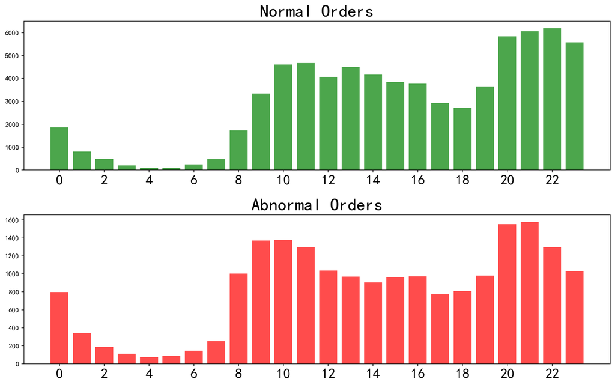

```python
plt.figure(figsize=(15,9),dpi=200)

plt.subplot(211)
plt.bar(OrderTime_normal.index,OrderTime_normal.values,color='green',alpha=0.7)
plt.title('Normal Orders',fontsize=25)
plt.xticks(ticks=range(0,24,2),fontsize=20)

plt.subplot(212)
plt.bar(OrderTime_ab.index,OrderTime_ab.values,color='r',alpha=0.7)
plt.title('Abnormal Orders',fontsize=25)
plt.xticks(ticks=range(0,24,2),fontsize=20)

plt.subplots_adjust(hspace=0.3)
plt.show()
```

可见，正常订单和异常订单在下单时间上的变化基本一致，下单时间很可能跟是否异常没有关系。

但还是要保留下单时间这一特征，并进行特征编码：（小时按24小时，分钟按前后半小时进行区分）

```python
train['order_time']
```

```
0        14:09:49
1        10:44:46
2        16:47:34
3        21:15:59
4        16:49:49
           ...
91863    23:56:01
91864    23:57:24
91865    23:54:34
91866    23:55:06
91867    23:58:59
Name: order_time, Length: 91868, dtype: object
```

```python
#建立编码函数（分钟）：
def encodeMinutes(column, train, test, newcolumn='time_minutes'):
    dic = {}
    feature = train.loc[:,column].apply(lambda x: (int(x[3:5])>30))    #得到的是bool类型
    unique_ = np.sort(feature.unique())
    for code, category in enumerate(unique_):
        dic[category] = code

    train[newcolumn] = feature
    train[newcolumn] = train[newcolumn].map(dic)

    #再用于测试集：
    test[newcolumn] = test.loc[:,column].apply(lambda x: (int(x[3:5])>30))
    test[newcolumn] = test[newcolumn].map(dic)

    return train,test
```

```python
#建立编码函数（小时）：
def encodeHours(column, train, test, newcolumn='time_hours'):
    dic = {}
    feature = train.loc[:,column].apply(lambda x: x[:2])
    unique_ = np.sort(feature.unique())
    for code, category in enumerate(unique_):
        dic[category] = code

    train[newcolumn] = feature
    train[newcolumn] = train[newcolumn].map(dic)

    #再用于测试集：
    test[newcolumn] = test.loc[:,column].apply(lambda x: x[:2])
    test[newcolumn] = test[newcolumn].map(dic)

    return train,test
```

```python
#运行函数：
train, test = encodeMinutes('order_time',train, test)
train, test = encodeHours('order_time',train, test)
```

```python
#删除原本的下单时间：
del(train['order_time'])
del(test['order_time'])
```

```python
#将处理后的数据单独保存：
train.to_csv('train.csv')
test.to_csv('test.csv')
```

```python
train = pd.read_csv('train.csv',index_col=0)
train.head()
```

|  | abnormal_label | order_id | cat | attribution | pro_id | pro_brand | total_money | total_quantity | order_source | pay_type | user_id | city | time_minutes | time_hours |
| --- | --- | --- | --- | --- | --- | --- | --- | --- | --- | --- | --- | --- | --- | --- |
| 0 | 1 | 4283851335 | 手机摄影数码 | POP | 8002042497 | 三星 | 766000.0 | 200 | 主站 | 合并支付 | dakehu_zy | 上海市 | 0 | 14 |
| 1 | 1 | 4281111595 | 家具建材 | POP | 8002199518 | 纬度空间 | 100.0 | 100 | 主站 | 合并支付 | nonscorpio | 广州市 | 1 | 10 |
| 2 | 0 | 4106833871 | 家居日用 | POP | 8002212182 | 品道天元 | 8800.0 | 100 | 主站 | 合并支付 | qq-edf69d7 | 深圳市 | 1 | 16 |
| 3 | 0 | 4253622967 | 电脑办公打印文仪 | POP | 8001748897 | 清华同方 | 880.0 | 100 | 主站 | 合并支付 | benson2570 | 宿迁市 | 0 | 21 |
| 4 | 0 | 4276159555 | 家居日用 | GO | 1000341307 | 乐扣乐扣 | 4900.0 | 100 | 主站 | 合并支付 | dakehu_zy | 西安市 | 1 | 16 |

## 2.3 支付方式（pay_type）

```python
train = pd.read_csv('train.csv',index_col=0)
test = pd.read_csv('test.csv',index_col=0)
```

```python
train['pay_type'].value_counts()
#共有5中支付方式。
```

```
合并支付    71893
货到付款    18321
当当支付     1226
在线支付      290
账户余额      138
Name: pay_type, dtype: int64
```

```python
#查看不同支付方式下，异常样本的比例：
train.groupby('pay_type')['abnormal_label'].mean()

#可见合并支付和在线支付的异常比例比较高。
```

```
pay_type
合并支付    0.275173
在线支付    0.251724
当当支付    0.044861
账户余额    0.028986
货到付款    0.000000
Name: abnormal_label, dtype: float64
```

```python
#在训练集和测试集中添加一列支付方式的异常率：
#定义函数：
def GroupByFeature(column, train, test, newcolumn):
    dic = dict(train.groupby(column)['abnormal_label'].mean())

    train[newcolumn] = train[column].map(dic)
    test[newcolumn] = test[column].map(dic)

    return train, test
#运行函数:
train,test = GroupByFeature('pay_type', train, test, 'ab-rate of pay_type')
```

```python
#建立支付方式的特征编码：
def encodePay(column, train, test):
    dic = {}
    feature = train.loc[:,column]
    unique_ = np.sort(feature.unique())
    for code, category in enumerate(unique_):
        dic[category] = code

    train[column] = train[column].map(dic)

    #再用于测试集：
    test[column] = test[column].map(dic)

    return train,test
```

```python
#运行函数：
train, test = encodePay('pay_type',train, test)
```

```python
train['pay_type'].value_counts()
#k可以看到，支付方式已经进行了编码。
```

```
0    71893
4    18321
2     1226
1      290
3      138
Name: pay_type, dtype: int64
```

```python
#将数据保存：
train.to_csv('train.csv')
test.to_csv('test.csv')
```

## 2.4 城市（city）

```python
train = pd.read_csv('train.csv',index_col=0)
test = pd.read_csv('test.csv',index_col=0)
```

```python
#查看城市：
train['city'].value_counts()
```

```
北京市        9578
上海市        4514
广州市        4157
深圳市        3717
天津市        2250
           ...
昌都地区          1
广东省其他城市       1
四川省其他城市       1
神农架林区         1
福建省其他城市       1
Name: city, Length: 362, dtype: int64
```

```python
#将城市按省份进行处理：
ChinaCity = pd.read_excel('ChinaCity.xls',index_col=1)
```

```python
ChinaCity
```

| 市级 | 省份 |
| --- | --- |
| 北京市 | 北京市 |
| 天津市 | 天津市 |
| 石家庄市 | 河北省 |
| 唐山市 | 河北省 |
| 秦皇岛市 | 河北省 |
| ... | ... |
| 辽宁省其他城市 | 辽宁省 |
| 四川省其他城市 | 四川省 |
| 广东省其他城市 | 广东省 |
| 云南省其他城市 | 云南省 |
| 福建省其他城市 | 福建省 |

409 rows × 1 columns

```python
#转化成Series，便于建立字典：
ChinaCity['省份']
```

```
市级
北京市        北京市
天津市        天津市
石家庄市       河北省
唐山市        河北省
秦皇岛市       河北省
          ...
辽宁省其他城市    辽宁省
四川省其他城市    四川省
广东省其他城市    广东省
云南省其他城市    云南省
福建省其他城市    福建省
Name: 省份, Length: 409, dtype: object
```

```python
train['province'] = train['city'].map(dict(ChinaCity['省份']))
```

```python
#检查是否有缺失值：
train['province'].isnull().sum()
```

```
0
```

```python
#计算每个省份的异常率：
train.groupby(['province'])['abnormal_label'].mean().sort_values(ascending=False)

#可见位置相对偏远的青海、内蒙古、西藏等地的订单异常率要明显高于其他省份。
```

```
province
青海省         0.382979
内蒙古自治区      0.309628
西藏自治区       0.272727
山西省         0.256000
甘肃省         0.255043
海南省         0.250318
江西省         0.245702
北京市         0.241595
陕西省         0.236769
河北省         0.236292
宁夏回族自治区     0.233161
重庆市         0.232558
新疆维吾尔自治区    0.231325
河南省         0.225344
吉林省         0.223310
广东省         0.222260
浙江省         0.219894
山东省         0.217832
湖北省         0.217329
福建省         0.215807
天津市         0.215111
江苏省         0.212617
辽宁省         0.211465
云南省         0.207724
湖南省         0.207155
上海市         0.206912
广西壮族自治区     0.201106
四川省         0.190524
黑龙江省        0.181818
安徽省         0.159470
贵州省         0.072279
Name: abnormal_label, dtype: float64
```

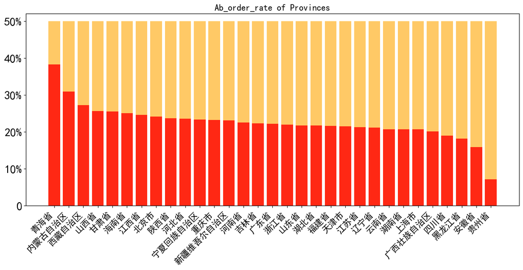

```python
#把异常率通过柱状图的形式表示：
df = train.groupby(['province'])['abnormal_label'].mean().sort_values(ascending=False)

plt.figure(figsize=(15,6),dpi=100)

plt.bar(df.index,0.5,color='orange',alpha=0.6)
plt.bar(df.index,df.values,color='r',alpha=0.8)
plt.title('Ab_order_rate of Provinces',fontsize=15)
plt.ylim(0,0.52)
plt.yticks(np.arange(0,0.6,0.1).tolist(),['0','10%','20%','30%','40%','50%'],fontsize=20)
plt.xticks(range(len(df)),df.index,fontsize=15,rotation=45,ha='right')
plt.show()
```

```python
#为训练集和测试集都添加“省份”这一特征：
train['province'] = train['city'].map(dict(ChinaCity['省份']))
test['province'] = test['city'].map(dict(ChinaCity['省份']))
```

```python
#在训练集和测试集中添加一列省份的异常率：
#定义函数：
def GroupByFeature(column, train, test, newcolumn):
    dic = dict(train.groupby(column)['abnormal_label'].mean())

    train[newcolumn] = train[column].map(dic)
    test[newcolumn] = test[column].map(dic)

    return train, test
#运行函数:
train,test = GroupByFeature('province', train, test, 'ab-rate of provinces')
```

```python
train.head()
```

|  | abnormal_label | order_id | cat | attribution | pro_id | pro_brand | total_money | total_quantity | order_source | pay_type | user_id | city | time_minutes | time_hours | ab-rate of pay_type | province | ab-rate of provinces |
| --- | --- | --- | --- | --- | --- | --- | --- | --- | --- | --- | --- | --- | --- | --- | --- | --- | --- |
| 0 | 1 | 4283851335 | 手机摄影数码 | POP | 8002042497 | 三星 | 766000.0 | 200 | 主站 | 0 | dakehu_zy | 上海市 | 0 | 14 | 0.275173 | 上海市 | 0.206912 |
| 1 | 1 | 4281111595 | 家具建材 | POP | 8002199518 | 纬度空间 | 100.0 | 100 | 主站 | 0 | nonscorpio | 广州市 | 1 | 10 | 0.275173 | 广东省 | 0.222260 |
| 2 | 0 | 4106833871 | 家居日用 | POP | 8002212182 | 品道天元 | 8800.0 | 100 | 主站 | 0 | qq-edf69d7 | 深圳市 | 1 | 16 | 0.275173 | 广东省 | 0.222260 |
| 3 | 0 | 4253622967 | 电脑办公打印文仪 | POP | 8001748897 | 清华同方 | 880.0 | 100 | 主站 | 0 | benson2570 | 宿迁市 | 0 | 21 | 0.275173 | 江苏省 | 0.212617 |
| 4 | 0 | 4276159555 | 家居日用 | GO | 1000341307 | 乐扣乐扣 | 4900.0 | 100 | 主站 | 0 | dakehu_zy | 西安市 | 1 | 16 | 0.275173 | 陕西省 | 0.236769 |

```python
#再次检查是否存在缺失值：
train.isnull().sum().sum()
```

```
0
```

```python
test.isnull().sum().sum()
```

```
6
```

```python
#测试集存在缺失值，进行缺失值的查看和处理：
test[test['province'].isnull()]
```

|  | abnormal_label | order_id | cat | attribution | pro_id | pro_brand | total_money | total_quantity | order_source | pay_type | user_id | city | time_minutes | time_hours | ab-rate of pay_type | province | ab-rate of provinces |
| --- | --- | --- | --- | --- | --- | --- | --- | --- | --- | --- | --- | --- | --- | --- | --- | --- | --- |
| 9393 | 1 | 4282946649 | 手机摄影数码 | GO | 1000376628 | 斐讯 | 399.0 | 1 | 主站 | 0 | aiai131452 | 山西省其他城市 | 1 | 7 | 0.275173 | NaN | NaN |
| 11613 | 0 | 3809475249 | 母婴用品玩具 | POP | 8001276188 | 大贸商 | 109.0 | 1 | 主站 | 0 | guoqingas | 山东省其他城市 | 1 | 10 | 0.275173 | NaN | NaN |
| 35611 | 0 | 4283977714 | 生活电器厨卫电器 | GO | 1000006426 | 飞利浦 | 299.0 | 1 | 主站 | 4 | 1587002842 | 江西省其他城市 | 1 | 13 | 0.000000 | NaN | NaN |

```python
test.loc[9393,'province'] = '山西省'
test.loc[11613,'province'] = '山东省'
test.loc[35611,'province'] = '江西省'
```

```python
ab_p = train.groupby(['province'])['abnormal_label'].mean()
test.loc[9393,'ab-rate of provinces'] = ab_p['山西省']
test.loc[11613,'ab-rate of provinces'] = ab_p['山东省']
test.loc[35611,'ab-rate of provinces'] = ab_p['江西省']
```

```python
test.isnull().sum().sum()

#测试集中的缺失值已处理。
```

```
0
```

```python
#建立城市和省份的的特征编码：
def encodeCityProvince(column, train, test):
    dic = {}
    feature = train.loc[:,column]
    unique_ = np.sort(feature.unique())
    for code, category in enumerate(unique_):
        dic[category] = code

    train[column] = train[column].map(dic)

    #再用于测试集：
    test[column] = test[column].map(dic)

    return train,test
```

```python
for column in ['city','province']:
    train, test = encodeCityProvince(column, train, test)
```

```python
train.head()
```

|  | abnormal_label | order_id | cat | attribution | pro_id | pro_brand | total_money | total_quantity | order_source | pay_type | user_id | city | time_minutes | time_hours | ab-rate of pay_type | province | ab-rate of provinces |
| --- | --- | --- | --- | --- | --- | --- | --- | --- | --- | --- | --- | --- | --- | --- | --- | --- | --- |
| 0 | 1 | 4283851335 | 手机摄影数码 | POP | 8002042497 | 三星 | 766000.0 | 200 | 主站 | 0 | dakehu_zy | 5 | 0 | 14 | 0.275173 | 0 | 0.206912 |
| 1 | 1 | 4281111595 | 家具建材 | POP | 8002199518 | 纬度空间 | 100.0 | 100 | 主站 | 0 | nonscorpio | 131 | 1 | 10 | 0.275173 | 11 | 0.222260 |
| 2 | 0 | 4106833871 | 家居日用 | POP | 8002212182 | 品道天元 | 8800.0 | 100 | 主站 | 0 | qq-edf69d7 | 220 | 1 | 16 | 0.275173 | 11 | 0.222260 |
| 3 | 0 | 4253622967 | 电脑办公打印文仪 | POP | 8001748897 | 清华同方 | 880.0 | 100 | 主站 | 0 | benson2570 | 115 | 0 | 21 | 0.275173 | 14 | 0.212617 |
| 4 | 0 | 4276159555 | 家居日用 | GO | 1000341307 | 乐扣乐扣 | 4900.0 | 100 | 主站 | 0 | dakehu_zy | 289 | 1 | 16 | 0.275173 | 28 | 0.236769 |

```python
#再次检查缺失值：
train.isnull().sum().sum()
```

```
0
```

```python
test.isnull().sum().sum()
```

```
3
```

```python
test.loc[test['city'].isnull(),'city']
```

```
9393    NaN
11613   NaN
35611   NaN
Name: city, dtype: float64
```

```python
train['city'].max()
```

```
361
```

```python
#将三个缺失值的特征编码粗略处理为362：
test.loc[test['city'].isnull(),'city'] = 362
```

```python
#将数据保存：
train.to_csv('train.csv')
test.to_csv('test.csv')
```

## 2.5 商品一级类别（cat）、订单渠道（order_source）、商品所属渠道（attribution）

```python
train = pd.read_csv('train.csv',index_col=0)
test = pd.read_csv('test.csv',index_col=0)
```

```python
train.groupby(['cat'])['abnormal_label'].mean().sort_values(ascending=False)
```

```
cat
箱包奢品         0.349172
钟表首饰         0.343860
图书音像         0.284768
服饰鞋帽         0.276811
家具建材         0.262840
手机摄影数码       0.261565
家居日用         0.235079
运动户外         0.234420
健康医疗         0.233255
汽车用品         0.229976
电脑办公打印文仪     0.215029
电视冰箱洗衣机空调    0.201848
食品酒水         0.199508
生活电器厨卫电器     0.193856
母婴用品玩具       0.173181
家纺寝居         0.173088
美妆个护         0.148900
Name: abnormal_label, dtype: float64
```

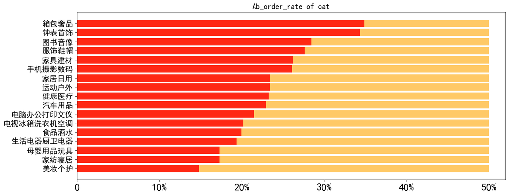

```python
#把异常率通过柱状图的形式表示：
df = train.groupby(['cat'])['abnormal_label'].mean().sort_values()

plt.figure(figsize=(15,6),dpi=100)

plt.barh(df.index,0.5,color='orange',alpha=0.6)
plt.barh(df.index,df.values,color='r',alpha=0.8)
plt.title('Ab_order_rate of cat',fontsize=15)
plt.xlim(0,0.52)
plt.xticks(np.arange(0,0.6,0.1).tolist(),['0','10%','20%','30%','40%','50%'],fontsize=20)
plt.yticks(range(len(df)),df.index,fontsize=15)
plt.show()
```

```python
train.groupby(['order_source'])['abnormal_label'].mean().sort_values(ascending=False)
```

```
order_source
手机团购          0.501931
抢购            0.400281
手机抢购          0.339863
团购            0.330159
手机站点          0.287742
当当            0.209125
主站            0.167849
do.site_id    0.097698
Name: abnormal_label, dtype: float64
```

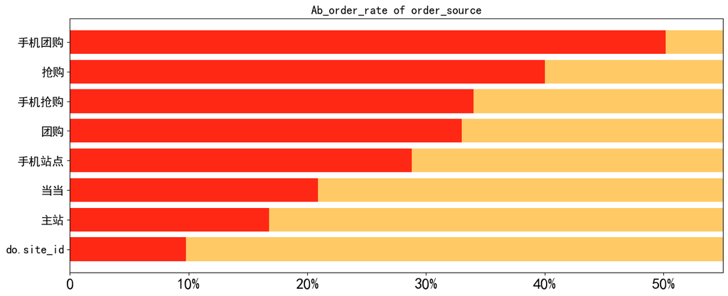

```python
#把异常率通过柱状图的形式表示：
df = train.groupby(['order_source'])['abnormal_label'].mean().sort_values()

plt.figure(figsize=(15,6),dpi=100)

plt.barh(df.index,0.55,color='orange',alpha=0.6)
plt.barh(df.index,df.values,color='r',alpha=0.8)
plt.title('Ab_order_rate of order_source',fontsize=15)
plt.xlim(0,0.55)
plt.xticks(np.arange(0,0.6,0.1).tolist(),['0','10%','20%','30%','40%','50%'],fontsize=20)
plt.yticks(range(len(df)),df.index,fontsize=15)
plt.show()
```

```python
train.groupby(['attribution'])['abnormal_label'].mean().sort_values(ascending=False)
```

```
attribution
POP    0.294727
GO     0.178732
Name: abnormal_label, dtype: float64
```

```python
#加入以上三个标签对应的新特征：
for i in ['cat','order_source','attribution']:
    train, test = GroupByFeature(i,train,test,'ab-rate of '+i)
```

```python
train.head()
```

|  | abnormal_label | order_id | cat | attribution | pro_id | pro_brand | total_money | total_quantity | order_source | pay_type | user_id | city | time_minutes | time_hours | ab-rate of pay_type | province | ab-rate of provinces | ab-rate of cat | ab-rate of order_source | ab-rate of attribution |
| --- | --- | --- | --- | --- | --- | --- | --- | --- | --- | --- | --- | --- | --- | --- | --- | --- | --- | --- | --- | --- |
| 0 | 1 | 4283851335 | 手机摄影数码 | POP | 8002042497 | 三星 | 766000.0 | 200 | 主站 | 0 | dakehu_zy | 5 | 0 | 14 | 0.275173 | 0 | 0.206912 | 0.261565 | 0.167849 | 0.294727 |
| 1 | 1 | 4281111595 | 家具建材 | POP | 8002199518 | 纬度空间 | 100.0 | 100 | 主站 | 0 | nonscorpio | 131 | 1 | 10 | 0.275173 | 11 | 0.222260 | 0.262840 | 0.167849 | 0.294727 |
| 2 | 0 | 4106833871 | 家居日用 | POP | 8002212182 | 品道天元 | 8800.0 | 100 | 主站 | 0 | qq-edf69d7 | 220 | 1 | 16 | 0.275173 | 11 | 0.222260 | 0.235079 | 0.167849 | 0.294727 |
| 3 | 0 | 4253622967 | 电脑办公打印文仪 | POP | 8001748897 | 清华同方 | 880.0 | 100 | 主站 | 0 | benson2570 | 115 | 0 | 21 | 0.275173 | 14 | 0.212617 | 0.215029 | 0.167849 | 0.294727 |
| 4 | 0 | 4276159555 | 家居日用 | GO | 1000341307 | 乐扣乐扣 | 4900.0 | 100 | 主站 | 0 | dakehu_zy | 289 | 1 | 16 | 0.275173 | 28 | 0.236769 | 0.235079 | 0.167849 | 0.178732 |

```python
#建立以上三个标签的的特征编码：
def encodeEasy(column, train, test):
    dic = {}
    feature = train.loc[:,column]
    unique_ = np.sort(feature.unique())
    for code, category in enumerate(unique_):
        dic[category] = code

    train[column] = train[column].map(dic)

    #再用于测试集：
    test[column] = test[column].map(dic)

    return train,test
```

```python
 for i in ['cat','order_source','attribution']:
    train, test = encodeEasy(i,train,test)
```

```python
train.head()
```

|  | abnormal_label | order_id | cat | attribution | pro_id | pro_brand | total_money | total_quantity | order_source | pay_type | user_id | city | time_minutes | time_hours | ab-rate of pay_type | province | ab-rate of provinces | ab-rate of cat | ab-rate of order_source | ab-rate of attribution |
| --- | --- | --- | --- | --- | --- | --- | --- | --- | --- | --- | --- | --- | --- | --- | --- | --- | --- | --- | --- | --- |
| 0 | 1 | 4283851335 | 5 | 1 | 8002042497 | 三星 | 766000.0 | 200 | 1 | 0 | dakehu_zy | 5 | 0 | 14 | 0.275173 | 0 | 0.206912 | 0.261565 | 0.167849 | 0.294727 |
| 1 | 1 | 4281111595 | 2 | 1 | 8002199518 | 纬度空间 | 100.0 | 100 | 1 | 0 | nonscorpio | 131 | 1 | 10 | 0.275173 | 11 | 0.222260 | 0.262840 | 0.167849 | 0.294727 |
| 2 | 0 | 4106833871 | 3 | 1 | 8002212182 | 品道天元 | 8800.0 | 100 | 1 | 0 | qq-edf69d7 | 220 | 1 | 16 | 0.275173 | 11 | 0.222260 | 0.235079 | 0.167849 | 0.294727 |
| 3 | 0 | 4253622967 | 10 | 1 | 8001748897 | 清华同方 | 880.0 | 100 | 1 | 0 | benson2570 | 115 | 0 | 21 | 0.275173 | 14 | 0.212617 | 0.215029 | 0.167849 | 0.294727 |
| 4 | 0 | 4276159555 | 3 | 0 | 1000341307 | 乐扣乐扣 | 4900.0 | 100 | 1 | 0 | dakehu_zy | 289 | 1 | 16 | 0.275173 | 28 | 0.236769 | 0.235079 | 0.167849 | 0.178732 |

```python
#将数据保存：
train.to_csv('train.csv')
test.to_csv('test.csv')
```

## 2.6 多类别字段——用户id（user_id）、商品id（pro_id）、品牌（pro_brand）

▶用户id（user_id）

```python
train = pd.read_csv('train.csv',index_col=0)
test = pd.read_csv('test.csv',index_col=0)
```

```python
#一共有多少用户：
len(train['user_id'].unique())
```

```
58488
```

```python
#其中只下了一单的用户有多少：
(train.groupby(['user_id'])['abnormal_label'].count() == 1).sum()

#这些只下了一单的用户是无法评估异常率的，所以赋予-1的用户异常率。
```

```
44137
```

```python
MulBuyRatio=train.groupby(['user_id'])['abnormal_label'].mean()[train.groupby(['user_id'])['abnormal_label'].count() != 1]
```

```python
MulBuyRatio.describe([0.6,0.7,0.8,0.9,0.99])

#可见，50%以上的用户是没有异常订单的。
```

```
count    14351.000000
mean         0.258921
std          0.347363
min          0.000000
50%          0.000000
60%          0.250000
70%          0.500000
80%          0.500000
90%          1.000000
99%          1.000000
max          1.000000
Name: abnormal_label, dtype: float64
```

▶商品id（pro_id）

```python
#通过商品销售数量来衡量不同商品id的交易量：
train.groupby(['pro_id'])['total_quantity'].sum().describe()

#可见，同一商品id的平均销售量只有6.32，
#因此销售数量小于10的，不予考虑异常率，只分析大于10的。
```

```
count    17252.000000
mean         6.321528
std         37.765090
min          1.000000
25%          1.000000
50%          1.000000
75%          3.000000
max       2606.000000
Name: total_quantity, dtype: float64
```

```python
ProIDRatio=train.groupby(['pro_id'])['abnormal_label'].mean()[train.groupby(['pro_id'])['total_quantity'].sum() >= 10]
```

```python
ProIDRatio.describe()

#可见，大部分商品id的异常率是低于30%的。
```

```
count    1748.000000
mean        0.229465
std         0.208118
min         0.000000
25%         0.083333
50%         0.176471
75%         0.324169
max         1.000000
Name: abnormal_label, dtype: float64
```

▶品牌（pro_brand）

```python
#通过商品销售数量来衡量不同品牌的交易量：
train.groupby(['pro_brand'])['total_quantity'].sum().describe()

#可见，同一商品id的平均销售量有43，
#我们对销售数量小于10的品牌，不予考虑异常率，只分析大于10的。
```

```
count    2507.000000
mean       43.501795
std       197.462143
min         1.000000
25%         2.000000
50%         5.000000
75%        18.000000
max      3904.000000
Name: total_quantity, dtype: float64
```

```python
ProBrandRatio=train.groupby(['pro_brand'])['abnormal_label'].mean()[train.groupby(['pro_brand'])['total_quantity'].sum() >= 10]
```

```python
ProBrandRatio.describe()

#可见，大部分品牌的异常率也是低于30%的。
```

```
count    882.000000
mean       0.246267
std        0.167831
min        0.000000
25%        0.133333
50%        0.217391
75%        0.333333
max        1.000000
Name: abnormal_label, dtype: float64
```

▶在训练集中，对订单只有1次的用户id、销售量小于10的商品id、销售量小于10的品牌均标记为-1，其他的标记为异常率； ▶在测试集中，已在训练集中出现的，沿用训练集的标记，新出现的标记为-1。

```python
df = pd.DataFrame(index=train['user_id'].unique())
df['ab-rate of user_id'] = -1
```

```python
df.head()
```

|  | ab-rate of user_id |
| --- | --- |
| dakehu_zy | -1 |
| nonscorpio | -1 |
| qq-edf69d7 | -1 |
| benson2570 | -1 |
| qq-3be293b | -1 |

```python
df.shape
```

```
(58488, 1)
```

```python
df.loc[MulBuyRatio.index,'ab-rate of user_id'] = MulBuyRatio
```

```python
dict(df['ab-rate of user_id'])
```

[output not shown]

[output cut: 946 more lines]

[output not shown]

```python
#将以上的字典映射到新的特征上：
train['ab-rate of user_id'] = train['user_id'].map(dict(df['ab-rate of user_id']))
```

```python
train['ab-rate of user_id'].head()
```

```
0    0.133333
1    0.333333
2    0.000000
3   -1.000000
4    0.133333
Name: ab-rate of user_id, dtype: float64
```

```python
#对测试集的数据，先检查是否在训练集中出现过：
dic = {}
for i in test['user_id']:
    if i in MulBuyRatio.index:
        dic[i] = MulBuyRatio[i]
    else:
        dic[i] = -1
```

```python
test['ab-rate of user_id'] = test['user_id'].map(dic)
```

```python
#把上述操作打包成函数，用于定义商品id和品牌：
def GroupByFeature2(column, train, test, newcolumn, ratio):
    df = pd.DataFrame(index=train[column].unique())
    df[newcolumn] = -1
    df.loc[ratio.index,newcolumn] = ratio

    train[newcolumn] = train[column].map(dict(df[newcolumn]))

    dic = {}
    for i in test[column]:
        if i in ratio.index:
            dic[i] = ratio[i]
        else:
            dic[i] = -1

    test[newcolumn] = test[column].map(dic)

    return train, test
```

```python
train, test = GroupByFeature2('pro_id', train, test, 'ab-rate of pro_id', ProIDRatio)
train, test = GroupByFeature2('pro_brand', train, test, 'ab-rate of pro_brand', ProBrandRatio)
```

```python
train.head()
```

|  | abnormal_label | order_id | cat | attribution | pro_id | pro_brand | total_money | total_quantity | order_source | pay_type | ... | time_hours | ab-rate of pay_type | province | ab-rate of provinces | ab-rate of cat | ab-rate of order_source | ab-rate of attribution | ab-rate of user_id | ab-rate of pro_id | ab-rate of pro_brand |
| --- | --- | --- | --- | --- | --- | --- | --- | --- | --- | --- | --- | --- | --- | --- | --- | --- | --- | --- | --- | --- | --- |
| 0 | 1 | 4283851335 | 5 | 1 | 8002042497 | 三星 | 766000.0 | 200 | 1 | 0 | ... | 14 | 0.275173 | 0 | 0.206912 | 0.261565 | 0.167849 | 0.294727 | 0.133333 | 1.000000 | 0.340804 |
| 1 | 1 | 4281111595 | 2 | 1 | 8002199518 | 纬度空间 | 100.0 | 100 | 1 | 0 | ... | 10 | 0.275173 | 11 | 0.222260 | 0.262840 | 0.167849 | 0.294727 | 0.333333 | 0.333333 | 0.250000 |
| 2 | 0 | 4106833871 | 3 | 1 | 8002212182 | 品道天元 | 8800.0 | 100 | 1 | 0 | ... | 16 | 0.275173 | 11 | 0.222260 | 0.235079 | 0.167849 | 0.294727 | 0.000000 | 0.238462 | 0.286842 |
| 3 | 0 | 4253622967 | 10 | 1 | 8001748897 | 清华同方 | 880.0 | 100 | 1 | 0 | ... | 21 | 0.275173 | 14 | 0.212617 | 0.215029 | 0.167849 | 0.294727 | -1.000000 | 0.296296 | 0.298387 |
| 4 | 0 | 4276159555 | 3 | 0 | 1000341307 | 乐扣乐扣 | 4900.0 | 100 | 1 | 0 | ... | 16 | 0.275173 | 28 | 0.236769 | 0.235079 | 0.167849 | 0.178732 | 0.133333 | 0.119565 | 0.179739 |

5 rows × 23 columns

▶特征编码：用户id（user_id）、商品id（pro_id）、品牌（pro_brand）

```python
def encodeComplex(column, train, test):
    dic = {}
    feature = train.loc[:,column]
    unique_ = np.sort(feature.unique())
    for code, category in enumerate(unique_):
        dic[category] = code

    train[column] = train[column].map(dic)

    #判断测试集中有没有训练集中未出现的类别：
    nullcheck = test[column].map(dic)
    while nullcheck.isnull().sum() >0:
        print('测试集中出现了训练集中未出现的类别！')
        newcategory = test.loc[nullcheck.isnull(),column].unique()
        for i in newcategory:
            dic[i] = len(dic)   #在原有dic后增加1的方式，为新类别编码
        nullcheck = test[column].map(dic)
    test[column] = nullcheck

    return train,test
```

```python
for column in ['user_id','pro_id','pro_brand']:
    train,test = encodeComplex(column, train, test)
```

```
测试集中出现了训练集中未出现的类别！
测试集中出现了训练集中未出现的类别！
测试集中出现了训练集中未出现的类别！
```

```python
train.head()
```

|  | abnormal_label | order_id | cat | attribution | pro_id | pro_brand | total_money | total_quantity | order_source | pay_type | ... | time_hours | ab-rate of pay_type | province | ab-rate of provinces | ab-rate of cat | ab-rate of order_source | ab-rate of attribution | ab-rate of user_id | ab-rate of pro_id | ab-rate of pro_brand |
| --- | --- | --- | --- | --- | --- | --- | --- | --- | --- | --- | --- | --- | --- | --- | --- | --- | --- | --- | --- | --- | --- |
| 0 | 1 | 4283851335 | 5 | 1 | 13080 | 199 | 766000.0 | 200 | 1 | 0 | ... | 14 | 0.275173 | 0 | 0.206912 | 0.261565 | 0.167849 | 0.294727 | 0.133333 | 1.000000 | 0.340804 |
| 1 | 1 | 4281111595 | 2 | 1 | 15075 | 1856 | 100.0 | 100 | 1 | 0 | ... | 10 | 0.275173 | 11 | 0.222260 | 0.262840 | 0.167849 | 0.294727 | 0.333333 | 0.333333 | 0.250000 |
| 2 | 0 | 4106833871 | 3 | 1 | 15212 | 676 | 8800.0 | 100 | 1 | 0 | ... | 16 | 0.275173 | 11 | 0.222260 | 0.235079 | 0.167849 | 0.294727 | 0.000000 | 0.238462 | 0.286842 |
| 3 | 0 | 4253622967 | 10 | 1 | 11454 | 1568 | 880.0 | 100 | 1 | 0 | ... | 21 | 0.275173 | 14 | 0.212617 | 0.215029 | 0.167849 | 0.294727 | -1.000000 | 0.296296 | 0.298387 |
| 4 | 0 | 4276159555 | 3 | 0 | 4800 | 262 | 4900.0 | 100 | 1 | 0 | ... | 16 | 0.275173 | 28 | 0.236769 | 0.235079 | 0.167849 | 0.178732 | 0.133333 | 0.119565 | 0.179739 |

5 rows × 23 columns

```python
#测试训练集中是否有缺失值：
test['user_id'].isnull().sum()
```

```
0
```

```python
test['pro_id'].isnull().sum()
```

```
0
```

```python
test['pro_brand'].isnull().sum()
```

```
0
```

```python
#将数据保存：
train.to_csv('train.csv')
test.to_csv('test.csv')
```

## 2.7 订单金额（total_money）和销售数量（total_quantity）

▶订单金额（total_money）

```python
train = pd.read_csv('train.csv',index_col=0)
test = pd.read_csv('test.csv',index_col=0)
```

```python
#查看异常订单和正常订单在订单金额上的区别：
ab = train.loc[train['abnormal_label'] ==1,'total_money']
normal = train.loc[train['abnormal_label'] !=1,'total_money']
```

```python
ab.describe()
```

```
count     19915.000000
mean        902.707100
std        5790.468611
min           0.500000
25%          49.000000
50%         118.000000
75%         688.000000
max      766000.000000
Name: total_money, dtype: float64
```

```python
normal.describe()

#可见，异常订单的订单金额均值和方差都比较高。
```

```
count     71953.000000
mean        606.823929
std        2160.500859
min           0.500000
25%          21.900000
50%          89.900000
75%         338.000000
max      383000.000000
Name: total_money, dtype: float64
```

```python
#绘制分布图观察一下：
import seaborn as sns
```

[output not shown]

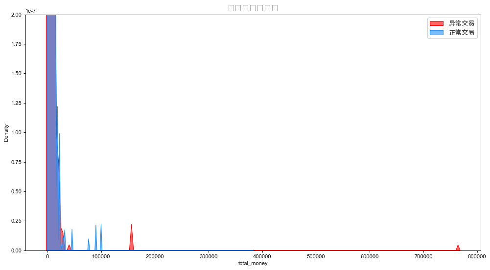

```python
plt.figure(figsize=(15,8),dpi=80)

sns.kdeplot(ab,
           shade=True,
           color='r',
           label='异常交易',
           alpha=0.6)

sns.kdeplot(normal,
           shade=True,
           color='dodgerblue',
           label='正常交易',
           alpha=0.6)

sns.set(style='whitegrid',font='simhei',font_scale=1.1)
plt.title('交易金额分布图',fontsize=18)
plt.ylim((0,0.0000002))
plt.legend()
plt.show()
```

```python
#可见38w以上的订单都是异常订单。
#需要对价格进行分箱，分析每个箱内的异常率：
from sklearn.preprocessing import KBinsDiscretizer as KBD
```

```python
enc = KBD(n_bins=10,encode='ordinal',strategy='kmeans')
```

```python
enc = enc.fit(pd.DataFrame(train['total_money']))
```

```python
train['binning_money'] = enc.transform(pd.DataFrame(train['total_money']))
```

```python
train.groupby(['binning_money'])['total_money'].min()
```

```
binning_money
0.0         0.5
1.0       956.0
2.0      2980.0
3.0      6666.0
4.0     13189.0
5.0     25790.0
6.0     71980.0
7.0    155999.0
8.0    383000.0
9.0    766000.0
Name: total_money, dtype: float64
```

```python
train.groupby(['binning_money'])['total_money'].max()
```

```
binning_money
0.0       954.0
1.0      2970.0
2.0      6638.0
3.0     12999.0
4.0     23998.0
5.0     45490.0
6.0     99840.0
7.0    155999.0
8.0    383000.0
9.0    766000.0
Name: total_money, dtype: float64
```

```python
df = pd.DataFrame(index=train.groupby(['binning_money'])['total_money'].max().index)
```

```python
df['bottom'] = train.groupby(['binning_money'])['total_money'].min()
df['top'] = train.groupby(['binning_money'])['total_money'].max()
```

```python
df
```

| binning_money | bottom | top |
| --- | --- | --- |
| 0.0 | 0.5 | 954.0 |
| 1.0 | 956.0 | 2970.0 |
| 2.0 | 2980.0 | 6638.0 |
| 3.0 | 6666.0 | 12999.0 |
| 4.0 | 13189.0 | 23998.0 |
| 5.0 | 25790.0 | 45490.0 |
| 6.0 | 71980.0 | 99840.0 |
| 7.0 | 155999.0 | 155999.0 |
| 8.0 | 383000.0 | 383000.0 |
| 9.0 | 766000.0 | 766000.0 |

```python
train.groupby(['binning_money'])['total_money'].mean()
```

```
binning_money
0.0       136.243951
1.0      1775.061962
2.0      4165.485313
3.0      9128.895833
4.0     16872.602041
5.0     32339.400000
6.0     85476.666667
7.0    155999.000000
8.0    383000.000000
9.0    766000.000000
Name: total_money, dtype: float64
```

```python
#可以将对应的分箱结果放置到训练集和测试集中去：
train['binning_money'] = enc.transform(pd.DataFrame(train['total_money']))
test['binning_money'] = enc.transform(pd.DataFrame(test['total_money']))
```

```python
#再将分箱的均值也放入：
dic = dict(train.groupby(['binning_money'])['total_money'].mean())
train['binning_money_mean'] = train['binning_money'].map(dic)
test['binning_money_mean'] = test['binning_money'].map(dic)
```

```python
train.head()
```

|  | abnormal_label | order_id | cat | attribution | pro_id | pro_brand | total_money | total_quantity | order_source | pay_type | ... | province | ab-rate of provinces | ab-rate of cat | ab-rate of order_source | ab-rate of attribution | ab-rate of user_id | ab-rate of pro_id | ab-rate of pro_brand | binning_money | binning_money_mean |
| --- | --- | --- | --- | --- | --- | --- | --- | --- | --- | --- | --- | --- | --- | --- | --- | --- | --- | --- | --- | --- | --- |
| 0 | 1 | 4283851335 | 5 | 1 | 13080 | 199 | 766000.0 | 200 | 1 | 0 | ... | 0 | 0.206912 | 0.261565 | 0.167849 | 0.294727 | 0.133333 | 1.000000 | 0.340804 | 9.0 | 766000.000000 |
| 1 | 1 | 4281111595 | 2 | 1 | 15075 | 1856 | 100.0 | 100 | 1 | 0 | ... | 11 | 0.222260 | 0.262840 | 0.167849 | 0.294727 | 0.333333 | 0.333333 | 0.250000 | 0.0 | 136.243951 |
| 2 | 0 | 4106833871 | 3 | 1 | 15212 | 676 | 8800.0 | 100 | 1 | 0 | ... | 11 | 0.222260 | 0.235079 | 0.167849 | 0.294727 | 0.000000 | 0.238462 | 0.286842 | 3.0 | 9128.895833 |
| 3 | 0 | 4253622967 | 10 | 1 | 11454 | 1568 | 880.0 | 100 | 1 | 0 | ... | 14 | 0.212617 | 0.215029 | 0.167849 | 0.294727 | -1.000000 | 0.296296 | 0.298387 | 0.0 | 136.243951 |
| 4 | 0 | 4276159555 | 3 | 0 | 4800 | 262 | 4900.0 | 100 | 1 | 0 | ... | 28 | 0.236769 | 0.235079 | 0.167849 | 0.178732 | 0.133333 | 0.119565 | 0.179739 | 2.0 | 4165.485313 |

5 rows × 25 columns

▶销售数量（total_quantity）

```python
ab = train.loc[train['abnormal_label'] ==1,'total_quantity']
normal = train.loc[train['abnormal_label'] !=1,'total_quantity']
```

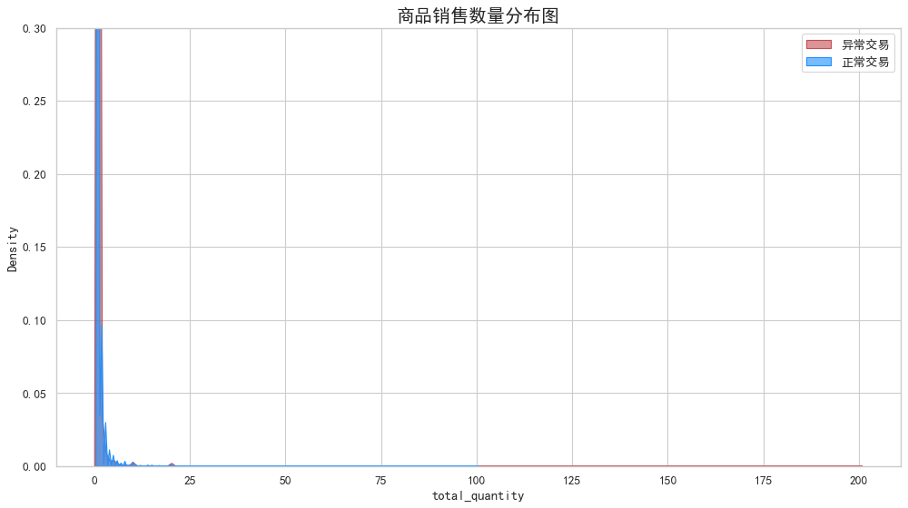

```python
plt.figure(figsize=(15,8),dpi=80)

sns.kdeplot(ab,
           shade=True,
           color='r',
           label='异常交易',
           alpha=0.6)

sns.kdeplot(normal,
           shade=True,
           color='dodgerblue',
           label='正常交易',
           alpha=0.6)

sns.set(style='whitegrid',font='simhei',font_scale=1.1)
plt.title('商品销售数量分布图',fontsize=18)
plt.ylim((0,0.3))
plt.legend()
plt.show()
```

```python
#可见销售数量在25个以下是，正常订单和异常订单没有较大区别。
#进行简单的二值化操作，大于25个为高风险，标记为1，反之标记为0。
train['binning_quantity'] = 0
test['binning_quantity'] = 0
train.loc[train['total_quantity'] > 25, 'binning_quantity'] = 1
test.loc[train['total_quantity'] > 25, 'binning_quantity'] = 1
```

```python
train.head()
```

|  | abnormal_label | order_id | cat | attribution | pro_id | pro_brand | total_money | total_quantity | order_source | pay_type | ... | ab-rate of provinces | ab-rate of cat | ab-rate of order_source | ab-rate of attribution | ab-rate of user_id | ab-rate of pro_id | ab-rate of pro_brand | binning_money | binning_money_mean | binning_quantity |
| --- | --- | --- | --- | --- | --- | --- | --- | --- | --- | --- | --- | --- | --- | --- | --- | --- | --- | --- | --- | --- | --- |
| 0 | 1 | 4283851335 | 5 | 1 | 13080 | 199 | 766000.0 | 200 | 1 | 0 | ... | 0.206912 | 0.261565 | 0.167849 | 0.294727 | 0.133333 | 1.000000 | 0.340804 | 9.0 | 766000.000000 | 1 |
| 1 | 1 | 4281111595 | 2 | 1 | 15075 | 1856 | 100.0 | 100 | 1 | 0 | ... | 0.222260 | 0.262840 | 0.167849 | 0.294727 | 0.333333 | 0.333333 | 0.250000 | 0.0 | 136.243951 | 1 |
| 2 | 0 | 4106833871 | 3 | 1 | 15212 | 676 | 8800.0 | 100 | 1 | 0 | ... | 0.222260 | 0.235079 | 0.167849 | 0.294727 | 0.000000 | 0.238462 | 0.286842 | 3.0 | 9128.895833 | 1 |
| 3 | 0 | 4253622967 | 10 | 1 | 11454 | 1568 | 880.0 | 100 | 1 | 0 | ... | 0.212617 | 0.215029 | 0.167849 | 0.294727 | -1.000000 | 0.296296 | 0.298387 | 0.0 | 136.243951 | 1 |
| 4 | 0 | 4276159555 | 3 | 0 | 4800 | 262 | 4900.0 | 100 | 1 | 0 | ... | 0.236769 | 0.235079 | 0.167849 | 0.178732 | 0.133333 | 0.119565 | 0.179739 | 2.0 | 4165.485313 | 1 |

5 rows × 26 columns

```python
#将数据保存：
train.to_csv('train.csv')
test.to_csv('test.csv')
```

# 3.构建电商订单异常检测模型

导入数据，按特征工程处理后的数据进行基础建模。

```python
import sklearn
from sklearn.ensemble import VotingClassifier
from sklearn.ensemble import GradientBoostingClassifier as GBC
from sklearn.ensemble import RandomForestClassifier as RFC
import xgboost as xgb
from sklearn.model_selection import KFold
from sklearn.model_selection import cross_val_score
```

```
C:\Program Files\Python\lib\site-packages\xgboost\compat.py:36: FutureWarning: pandas.Int64Index is deprecated and will be removed from pandas in a future version. Use pandas.Index with the appropriate dtype instead.
  from pandas import MultiIndex, Int64Index
```

```python
train = pd.read_csv('train.csv',index_col=0)
test = pd.read_csv('test.csv',index_col=0)
```

```python
train.head()
```

|  | abnormal_label | order_id | cat | attribution | pro_id | pro_brand | total_money | total_quantity | order_source | pay_type | ... | ab-rate of provinces | ab-rate of cat | ab-rate of order_source | ab-rate of attribution | ab-rate of user_id | ab-rate of pro_id | ab-rate of pro_brand | binning_money | binning_money_mean | binning_quantity |
| --- | --- | --- | --- | --- | --- | --- | --- | --- | --- | --- | --- | --- | --- | --- | --- | --- | --- | --- | --- | --- | --- |
| 0 | 1 | 4283851335 | 5 | 1 | 13080 | 199 | 766000.0 | 200 | 1 | 0 | ... | 0.206912 | 0.261565 | 0.167849 | 0.294727 | 0.133333 | 1.000000 | 0.340804 | 9.0 | 766000.000000 | 1 |
| 1 | 1 | 4281111595 | 2 | 1 | 15075 | 1856 | 100.0 | 100 | 1 | 0 | ... | 0.222260 | 0.262840 | 0.167849 | 0.294727 | 0.333333 | 0.333333 | 0.250000 | 0.0 | 136.243951 | 1 |
| 2 | 0 | 4106833871 | 3 | 1 | 15212 | 676 | 8800.0 | 100 | 1 | 0 | ... | 0.222260 | 0.235079 | 0.167849 | 0.294727 | 0.000000 | 0.238462 | 0.286842 | 3.0 | 9128.895833 | 1 |
| 3 | 0 | 4253622967 | 10 | 1 | 11454 | 1568 | 880.0 | 100 | 1 | 0 | ... | 0.212617 | 0.215029 | 0.167849 | 0.294727 | -1.000000 | 0.296296 | 0.298387 | 0.0 | 136.243951 | 1 |
| 4 | 0 | 4276159555 | 3 | 0 | 4800 | 262 | 4900.0 | 100 | 1 | 0 | ... | 0.236769 | 0.235079 | 0.167849 | 0.178732 | 0.133333 | 0.119565 | 0.179739 | 2.0 | 4165.485313 | 1 |

5 rows × 26 columns

```python
test.head()
```

|  | abnormal_label | order_id | cat | attribution | pro_id | pro_brand | total_money | total_quantity | order_source | pay_type | ... | ab-rate of provinces | ab-rate of cat | ab-rate of order_source | ab-rate of attribution | ab-rate of user_id | ab-rate of pro_id | ab-rate of pro_brand | binning_money | binning_money_mean | binning_quantity |
| --- | --- | --- | --- | --- | --- | --- | --- | --- | --- | --- | --- | --- | --- | --- | --- | --- | --- | --- | --- | --- | --- |
| 0 | 1 | 4276537082 | 11 | 1 | 12689 | 1406 | 19900.0 | 100 | 1 | 0 | ... | 0.215807 | 0.201848 | 0.167849 | 0.294727 | -1.000000 | 0.000000 | 0.083333 | 4.0 | 16872.602041 | 1 |
| 1 | 0 | 3977175284 | 5 | 1 | 15601 | 339 | 990.0 | 100 | 1 | 0 | ... | 0.215807 | 0.261565 | 0.167849 | 0.294727 | -1.000000 | 0.153846 | 0.372263 | 1.0 | 1775.061962 | 1 |
| 2 | 0 | 4245023523 | 2 | 1 | 15075 | 1856 | 100.0 | 100 | 1 | 0 | ... | 0.222260 | 0.262840 | 0.167849 | 0.294727 | 0.333333 | 0.333333 | 0.250000 | 0.0 | 136.243951 | 1 |
| 3 | 0 | 4284515355 | 9 | 1 | 17252 | 393 | 21450.0 | 50 | 1 | 0 | ... | 0.222260 | 0.193856 | 0.167849 | 0.294727 | -1.000000 | -1.000000 | 0.162162 | 4.0 | 16872.602041 | 1 |
| 4 | 0 | 4284735147 | 3 | 1 | 15111 | 797 | 1950.0 | 50 | 1 | 0 | ... | 0.215111 | 0.235079 | 0.167849 | 0.294727 | -1.000000 | 0.248485 | 0.240741 | 1.0 | 1775.061962 | 1 |

5 rows × 26 columns

```python
Xtrain = train.iloc[:,1:]
Xtest = test.iloc[:,1:]
Ytrain = train.iloc[:,0]
Ytest = test.iloc[:,0]
```

```python
Xtrain.head()
```

|  | order_id | cat | attribution | pro_id | pro_brand | total_money | total_quantity | order_source | pay_type | user_id | ... | ab-rate of provinces | ab-rate of cat | ab-rate of order_source | ab-rate of attribution | ab-rate of user_id | ab-rate of pro_id | ab-rate of pro_brand | binning_money | binning_money_mean | binning_quantity |
| --- | --- | --- | --- | --- | --- | --- | --- | --- | --- | --- | --- | --- | --- | --- | --- | --- | --- | --- | --- | --- | --- |
| 0 | 4283851335 | 5 | 1 | 13080 | 199 | 766000.0 | 200 | 1 | 0 | 18575 | ... | 0.206912 | 0.261565 | 0.167849 | 0.294727 | 0.133333 | 1.000000 | 0.340804 | 9.0 | 766000.000000 | 1 |
| 1 | 4281111595 | 2 | 1 | 15075 | 1856 | 100.0 | 100 | 1 | 0 | 34757 | ... | 0.222260 | 0.262840 | 0.167849 | 0.294727 | 0.333333 | 0.333333 | 0.250000 | 0.0 | 136.243951 | 1 |
| 2 | 4106833871 | 3 | 1 | 15212 | 676 | 8800.0 | 100 | 1 | 0 | 42323 | ... | 0.222260 | 0.235079 | 0.167849 | 0.294727 | 0.000000 | 0.238462 | 0.286842 | 3.0 | 9128.895833 | 1 |
| 3 | 4253622967 | 10 | 1 | 11454 | 1568 | 880.0 | 100 | 1 | 0 | 15730 | ... | 0.212617 | 0.215029 | 0.167849 | 0.294727 | -1.000000 | 0.296296 | 0.298387 | 0.0 | 136.243951 | 1 |
| 4 | 4276159555 | 3 | 0 | 4800 | 262 | 4900.0 | 100 | 1 | 0 | 18575 | ... | 0.236769 | 0.235079 | 0.167849 | 0.178732 | 0.133333 | 0.119565 | 0.179739 | 2.0 | 4165.485313 | 1 |

5 rows × 25 columns

```python
dtrain = xgb.DMatrix(Xtrain,Ytrain)
dtest = xgb.DMatrix(Xtest,Ytest)
```

```
C:\Program Files\Python\lib\site-packages\xgboost\data.py:262: FutureWarning: pandas.Int64Index is deprecated and will be removed from pandas in a future version. Use pandas.Index with the appropriate dtype instead.
  elif isinstance(data.columns, (pd.Int64Index, pd.RangeIndex)):
```

```python
#使用随机森林和GBDC分别进行预测观察结果：
rf = RFC(n_estimators=200,random_state=1412)
gbdc = GBC(n_estimators=200,random_state=1412)
```

```python
#KFold交叉验证：
cv = KFold(n_splits=5,shuffle=True,random_state=1412)
```

```python
#GBDC：
result_gbdc_cv = cross_val_score(gbdc,Xtrain,Ytrain,cv=cv)
```

```python
result_gbdc_cv.mean()
```

```
0.8797078376902572
```

```python
result_gbdc_cv.var()
```

```
1.0607271170855335e-06
```

```python
#随机森林：
result_rf_cv = cross_val_score(rf,Xtrain,Ytrain,cv=cv)
```

```python
result_rf_cv.mean()
```

```
0.875255818302292
```

```python
result_rf_cv.var()
```

```
9.497350843595869e-07
```

```python
#使用XGBoost观察结果：
param = {'objective':'binary:logistic',    #交差熵损失
        'eval_metric':'error',    #只支持错误率
        'seed':1412}
```

```python
xgbcv = xgb.cv(param, dtrain,
              num_boost_round=200,
              nfold=5, seed=1412, shuffle=True)
```

```python
xgbcv
```

|  | train-error-mean | train-error-std | test-error-mean | test-error-std |
| --- | --- | --- | --- | --- |
| 0 | 0.125560 | 0.000901 | 0.127161 | 0.001774 |
| 1 | 0.123054 | 0.000910 | 0.124799 | 0.001228 |
| 2 | 0.122368 | 0.000814 | 0.124080 | 0.000671 |
| 3 | 0.121359 | 0.000337 | 0.123645 | 0.001491 |
| 4 | 0.120858 | 0.000701 | 0.123329 | 0.001151 |
| ... | ... | ... | ... | ... |
| 195 | 0.065377 | 0.001125 | 0.123678 | 0.000637 |
| 196 | 0.065148 | 0.001215 | 0.123536 | 0.000573 |
| 197 | 0.064903 | 0.001189 | 0.123754 | 0.000405 |
| 198 | 0.064829 | 0.001244 | 0.123775 | 0.000566 |
| 199 | 0.064470 | 0.001174 | 0.123928 | 0.000592 |

200 rows × 4 columns

```python
1 - xgbcv.loc[199,'test-error-mean']
```

```
0.8760722
```

观察三个模型的AUC分数：

```python
#每次训练完毕后，要重新设置类
rf = RFC(n_estimators=200,random_state=1412)
gbdc = GBC(n_estimators=200,random_state=1412)
cv = KFold(n_splits=5,shuffle=True,random_state=1412)
```

```python
#GBDC：
result_gbdc_cv = cross_val_score(gbdc,Xtrain,Ytrain,cv=cv,scoring='roc_auc')
```

```python
result_gbdc_cv.mean()
```

```
0.9352066486941155
```

```python
result_gbdc_cv.var()
```

```
4.5531915504519046e-07
```

```python
#随机森林：
result_rf_cv = cross_val_score(rf,Xtrain,Ytrain,cv=cv,scoring='roc_auc')
```

```python
result_rf_cv.mean()
```

```
0.9280744636325474
```

```python
result_rf_cv.var()
```

```
1.7339775089957994e-06
```

```python
#XGBoost：
param2 = {'objective':'binary:logistic',    #交差熵损失
        'eval_metric':'auc',    #只支持错误率
        'seed':1412}
```

```python
xgbcv = xgb.cv(param2, dtrain,
              num_boost_round=200,
              nfold=5, seed=1412, shuffle=True)
```

```python
xgbcv.loc[199,'test-auc-mean']
```

```
0.933489
```

```python
xgbcv.loc[199,'test-auc-std']**2
```

```
2.722204000000003e-07
```

后续工作可以根本AUC分数进行模型的调参。